# Problem Statement

A US-based housing company named Surprise Housing has decided to enter the Australian market. The company uses data analytics to purchase houses at a price below their actual values and flip them on at a higher price. For the same purpose, the company has collected a data set from the sale of houses in Australia. The data is provided in the CSV file below.

The company is looking at prospective properties to buy to enter the market. You are required to build a regression model using regularisation in order to predict the actual value of the prospective properties and decide whether to invest in them or not.

The company wants to know:

Which variables are significant in predicting the price of a house, and

How well those variables describe the price of a house.

Also, determine the optimal value of lambda for ridge and lasso regression.

```python
#load library
import numpy as np
import pandas as pd
import matplotlib.pyplot as plt
import seaborn as sns

%matplotlib inline
```

```python
#ignore warnings
import warnings
warnings.filterwarnings('ignore')
```

```python
#import data
data = pd.read_csv("train.csv")
```

```python
#display options
pd.set_option('display.max_columns',None)
```

```python
#data first 5 rows
data.head()
```

|  | Id | MSSubClass | MSZoning | LotFrontage | LotArea | Street | Alley | LotShape | LandContour | Utilities | LotConfig | LandSlope | Neighborhood | Condition1 | Condition2 | BldgType | HouseStyle | OverallQual | OverallCond | YearBuilt | YearRemodAdd | RoofStyle | RoofMatl | Exterior1st | Exterior2nd | MasVnrType | MasVnrArea | ExterQual | ExterCond | … |
| --- | --- | --- | --- | --- | --- | --- | --- | --- | --- | --- | --- | --- | --- | --- | --- | --- | --- | --- | --- | --- | --- | --- | --- | --- | --- | --- | --- | --- | --- | --- |
| 0 | 1 | 60 | RL | 65.0 | 8450 | Pave | NaN | Reg | Lvl | AllPub | Inside | Gtl | CollgCr | Norm | Norm | 1Fam | 2Story | 7 | 5 | 2003 | 2003 | Gable | CompShg | VinylSd | VinylSd | BrkFace | 196.0 | Gd | TA | … |
| 1 | 2 | 20 | RL | 80.0 | 9600 | Pave | NaN | Reg | Lvl | AllPub | FR2 | Gtl | Veenker | Feedr | Norm | 1Fam | 1Story | 6 | 8 | 1976 | 1976 | Gable | CompShg | MetalSd | MetalSd | None | 0.0 | TA | TA | … |
| 2 | 3 | 60 | RL | 68.0 | 11250 | Pave | NaN | IR1 | Lvl | AllPub | Inside | Gtl | CollgCr | Norm | Norm | 1Fam | 2Story | 7 | 5 | 2001 | 2002 | Gable | CompShg | VinylSd | VinylSd | BrkFace | 162.0 | Gd | TA | … |
| 3 | 4 | 70 | RL | 60.0 | 9550 | Pave | NaN | IR1 | Lvl | AllPub | Corner | Gtl | Crawfor | Norm | Norm | 1Fam | 2Story | 7 | 5 | 1915 | 1970 | Gable | CompShg | Wd Sdng | Wd Shng | None | 0.0 | TA | TA | … |
| 4 | 5 | 60 | RL | 84.0 | 14260 | Pave | NaN | IR1 | Lvl | AllPub | FR2 | Gtl | NoRidge | Norm | Norm | 1Fam | 2Story | 8 | 5 | 2000 | 2000 | Gable | CompShg | VinylSd | VinylSd | BrkFace | 350.0 | Gd | TA | … |

```python
#data shape , no of rows,columns
data.shape
```

```
(1460, 81)
```

```python
#data info
data.info()
```

```
<class 'pandas.core.frame.DataFrame'>
RangeIndex: 1460 entries, 0 to 1459
Data columns (total 81 columns):
 #   Column         Non-Null Count  Dtype
---  ------         --------------  -----
 0   Id             1460 non-null   int64
 1   MSSubClass     1460 non-null   int64
 2   MSZoning       1460 non-null   object
 3   LotFrontage    1201 non-null   float64
 4   LotArea        1460 non-null   int64
 5   Street         1460 non-null   object
 6   Alley          91 non-null     object
 7   LotShape       1460 non-null   object
 8   LandContour    1460 non-null   object
 9   Utilities      1460 non-null   object
```

[output cut: 73 more lines]

# Target Variable : SalePrice

# Handling Missing Values

```python
#based on the data dict three variable is there which is having numeric values but its a category
# MSSubClass, OverallQual, OverallCond

def convertDtype(colList,dtype):
    for col in colList:
        data[col] = data[col].astype(dtype)
```

```python
#Convert to object dtype
convertDtype(['MSSubClass', 'OverallQual', 'OverallCond'],'object')
```

```python
#check dtype after conversion
data[['MSSubClass', 'OverallQual', 'OverallCond']].info()
```

```
<class 'pandas.core.frame.DataFrame'>
RangeIndex: 1460 entries, 0 to 1459
Data columns (total 3 columns):
 #   Column       Non-Null Count  Dtype
---  ------       --------------  -----
 0   MSSubClass   1460 non-null   object
 1   OverallQual  1460 non-null   object
 2   OverallCond  1460 non-null   object
dtypes: object(3)
memory usage: 34.3+ KB
```

```python
#column having NA as its values rather than treating it as null value
col_na_val = ['Alley','BsmtQual','BsmtCond','BsmtExposure','BsmtFinType1','BsmtFinType2','GarageType','GarageFinish','GarageQual',
              'GarageCond','PoolQC','Fence','MiscFeature','FireplaceQu']
```

```python
#where as Alley NA shows : No Alley Access , so first replace NA Alley values with as No_alley
def replaceColValues(colList):
    for col in colList:
        data[col] = data[col].replace(np.nan,'NO_'+col)
```

```python
#replace NA as no_alley
replaceColValues(col_na_val)
```

```python
#check values after replacement
data['Alley'].value_counts()
```

```
NO_Alley    1369
Grvl          50
Pave          41
Name: Alley, dtype: int64
```

```python
#select object dtypes columns
d_obj = data.select_dtypes(include="object")
```

```python
# no of columns having dtype as Object
d_obj.shape
```

```
(1460, 46)
```

```python
#apart from object dtypes like int, float
d_other = data.select_dtypes(exclude="object")
```

```python
#other than object dtypes columns
d_other.columns
```

```
Index(['Id', 'LotFrontage', 'LotArea', 'YearBuilt', 'YearRemodAdd',
       'MasVnrArea', 'BsmtFinSF1', 'BsmtFinSF2', 'BsmtUnfSF', 'TotalBsmtSF',
       '1stFlrSF', '2ndFlrSF', 'LowQualFinSF', 'GrLivArea', 'BsmtFullBath',
       'BsmtHalfBath', 'FullBath', 'HalfBath', 'BedroomAbvGr', 'KitchenAbvGr',
       'TotRmsAbvGrd', 'Fireplaces', 'GarageYrBlt', 'GarageCars', 'GarageArea',
       'WoodDeckSF', 'OpenPorchSF', 'EnclosedPorch', '3SsnPorch',
       'ScreenPorch', 'PoolArea', 'MiscVal', 'MoSold', 'YrSold', 'SalePrice'],
      dtype='object')
```

```python
#object having object as dtype : categorical variable
d_obj.columns
```

```
Index(['MSSubClass', 'MSZoning', 'Street', 'Alley', 'LotShape', 'LandContour',
       'Utilities', 'LotConfig', 'LandSlope', 'Neighborhood', 'Condition1',
       'Condition2', 'BldgType', 'HouseStyle', 'OverallQual', 'OverallCond',
       'RoofStyle', 'RoofMatl', 'Exterior1st', 'Exterior2nd', 'MasVnrType',
       'ExterQual', 'ExterCond', 'Foundation', 'BsmtQual', 'BsmtCond',
       'BsmtExposure', 'BsmtFinType1', 'BsmtFinType2', 'Heating', 'HeatingQC',
       'CentralAir', 'Electrical', 'KitchenQual', 'Functional', 'FireplaceQu',
       'GarageType', 'GarageFinish', 'GarageQual', 'GarageCond', 'PavedDrive',
       'PoolQC', 'Fence', 'MiscFeature', 'SaleType', 'SaleCondition'],
      dtype='object')
```

```python
#check first 5 rows
data[d_obj.columns].head()
```

|  | MSSubClass | MSZoning | Street | Alley | LotShape | LandContour | Utilities | LotConfig | LandSlope | Neighborhood | Condition1 | Condition2 | BldgType | HouseStyle | OverallQual | OverallCond | RoofStyle | RoofMatl | Exterior1st | Exterior2nd | MasVnrType | ExterQual | ExterCond | Foundation | BsmtQual | BsmtCond | BsmtExposure | BsmtFinType1 | BsmtFinType2 | … |
| --- | --- | --- | --- | --- | --- | --- | --- | --- | --- | --- | --- | --- | --- | --- | --- | --- | --- | --- | --- | --- | --- | --- | --- | --- | --- | --- | --- | --- | --- | --- |
| 0 | 60 | RL | Pave | NO_Alley | Reg | Lvl | AllPub | Inside | Gtl | CollgCr | Norm | Norm | 1Fam | 2Story | 7 | 5 | Gable | CompShg | VinylSd | VinylSd | BrkFace | Gd | TA | PConc | Gd | TA | No | GLQ | Unf | … |
| 1 | 20 | RL | Pave | NO_Alley | Reg | Lvl | AllPub | FR2 | Gtl | Veenker | Feedr | Norm | 1Fam | 1Story | 6 | 8 | Gable | CompShg | MetalSd | MetalSd | None | TA | TA | CBlock | Gd | TA | Gd | ALQ | Unf | … |
| 2 | 60 | RL | Pave | NO_Alley | IR1 | Lvl | AllPub | Inside | Gtl | CollgCr | Norm | Norm | 1Fam | 2Story | 7 | 5 | Gable | CompShg | VinylSd | VinylSd | BrkFace | Gd | TA | PConc | Gd | TA | Mn | GLQ | Unf | … |
| 3 | 70 | RL | Pave | NO_Alley | IR1 | Lvl | AllPub | Corner | Gtl | Crawfor | Norm | Norm | 1Fam | 2Story | 7 | 5 | Gable | CompShg | Wd Sdng | Wd Shng | None | TA | TA | BrkTil | TA | Gd | No | ALQ | Unf | … |
| 4 | 60 | RL | Pave | NO_Alley | IR1 | Lvl | AllPub | FR2 | Gtl | NoRidge | Norm | Norm | 1Fam | 2Story | 8 | 5 | Gable | CompShg | VinylSd | VinylSd | BrkFace | Gd | TA | PConc | Gd | TA | Av | GLQ | Unf | … |

```python
# check values
data['PoolQC'].value_counts()
```

```
NO_PoolQC    1453
Gd              3
Fa              2
Ex              2
Name: PoolQC, dtype: int64
```

```python
# delete as not required now
del d_obj
```

```python
# delete as not required now
del d_other
```

```python
#check null values percentage
missing_df = round(100*(data.isnull().sum()/data.shape[0]),2).to_frame('Nulls').sort_values(by='Nulls',ascending=False)
missing_df[missing_df.Nulls>0]
```

|  | Nulls |
| --- | --- |
| LotFrontage | 17.74 |
| GarageYrBlt | 5.55 |
| MasVnrType | 0.55 |
| MasVnrArea | 0.55 |
| Electrical | 0.07 |

```python
# for MasVnrType is having None type not NA , so drop its NA rows
data['MasVnrType'].isnull().sum()
```

```
8
```

```python
data['MasVnrType'].fillna('None', inplace=True)
```

```python
data['MasVnrType'].isnull().sum()
```

```
0
```

```python
#Electrical column
data['Electrical'].isnull().sum()
```

```
1
```

```python
data[data['Electrical'].isnull()]
```

|  | Id | MSSubClass | MSZoning | LotFrontage | LotArea | Street | Alley | LotShape | LandContour | Utilities | LotConfig | LandSlope | Neighborhood | Condition1 | Condition2 | BldgType | HouseStyle | OverallQual | OverallCond | YearBuilt | YearRemodAdd | RoofStyle | RoofMatl | Exterior1st | Exterior2nd | MasVnrType | MasVnrArea | ExterQual | ExterCond | … |
| --- | --- | --- | --- | --- | --- | --- | --- | --- | --- | --- | --- | --- | --- | --- | --- | --- | --- | --- | --- | --- | --- | --- | --- | --- | --- | --- | --- | --- | --- | --- |
| 1379 | 1380 | 80 | RL | 73.0 | 9735 | Pave | NO_Alley | Reg | Lvl | AllPub | Inside | Gtl | Timber | Norm | Norm | 1Fam | SLvl | 5 | 5 | 2006 | 2007 | Gable | CompShg | VinylSd | VinylSd | None | 0.0 | TA | TA | … |

```python
#drop 'Electrical' NA row
data = data[~data['Electrical'].isnull()]
```

```python
data.shape
```

```
(1459, 81)
```

```python
# so three columns are having missing values : LotFrontage, GarageYrBlt , MasVnrArea
```

```python
#check details related to above columns having Missing Values
data[missing_df[missing_df.Nulls>0].index].describe()
```

|  | LotFrontage | GarageYrBlt | MasVnrArea |
| --- | --- | --- | --- |
| count | 1200.000000 | 1378.000000 | 1451.00000 |
| mean | 70.047500 | 1978.485486 | 103.75672 |
| std | 24.294727 | 24.686740 | 181.10815 |
| min | 21.000000 | 1900.000000 | 0.00000 |
| 25% | 59.000000 | 1961.000000 | 0.00000 |
| 50% | 69.000000 | 1980.000000 | 0.00000 |
| 75% | 80.000000 | 2002.000000 | 166.00000 |
| max | 313.000000 | 2010.000000 | 1600.00000 |

```python
#replace with median value : LotFrontage
data.loc[np.isnan(data['LotFrontage']),'LotFrontage'] = data['LotFrontage'].median()
```

```python
#check null values after replacement
data['LotFrontage'].isnull().sum()
```

```
0
```

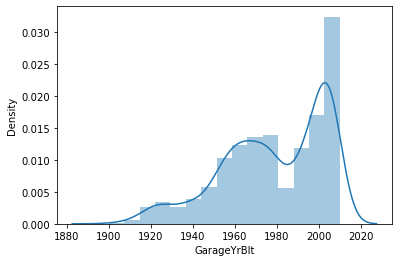

```python
sns.distplot(data['GarageYrBlt'])
plt.show()
```

```python
#replace with median value : GarageYrBlt
data.loc[np.isnan(data['GarageYrBlt']),'GarageYrBlt'] = data['GarageYrBlt'].median()
```

```python
#check null after replcemenet
data['GarageYrBlt'].isnull().sum()
```

```
0
```

## for MasVnrArea

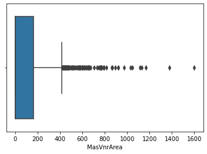

```python
sns.boxplot(data['MasVnrArea'])
plt.show()
```

```python
#details
data['MasVnrArea'].describe()
```

```
count    1451.00000
mean      103.75672
std       181.10815
min         0.00000
25%         0.00000
50%         0.00000
75%       166.00000
max      1600.00000
Name: MasVnrArea, dtype: float64
```

#### very large diff in range ( min / max ) as std deviation is also very high so lets drop the rows which is having MasVnrArea as null

```python
data[data['MasVnrArea'].isnull()]
```

|  | Id | MSSubClass | MSZoning | LotFrontage | LotArea | Street | Alley | LotShape | LandContour | Utilities | LotConfig | LandSlope | Neighborhood | Condition1 | Condition2 | BldgType | HouseStyle | OverallQual | OverallCond | YearBuilt | YearRemodAdd | RoofStyle | RoofMatl | Exterior1st | Exterior2nd | MasVnrType | MasVnrArea | ExterQual | ExterCond | … |
| --- | --- | --- | --- | --- | --- | --- | --- | --- | --- | --- | --- | --- | --- | --- | --- | --- | --- | --- | --- | --- | --- | --- | --- | --- | --- | --- | --- | --- | --- | --- |
| 234 | 235 | 60 | RL | 69.0 | 7851 | Pave | NO_Alley | Reg | Lvl | AllPub | Inside | Gtl | Gilbert | Norm | Norm | 1Fam | 2Story | 6 | 5 | 2002 | 2002 | Gable | CompShg | VinylSd | VinylSd | None | NaN | Gd | TA | … |
| 529 | 530 | 20 | RL | 69.0 | 32668 | Pave | NO_Alley | IR1 | Lvl | AllPub | CulDSac | Gtl | Crawfor | Norm | Norm | 1Fam | 1Story | 6 | 3 | 1957 | 1975 | Hip | CompShg | Wd Sdng | Stone | None | NaN | Gd | TA | … |
| 650 | 651 | 60 | FV | 65.0 | 8125 | Pave | NO_Alley | Reg | Lvl | AllPub | Inside | Gtl | Somerst | Norm | Norm | 1Fam | 2Story | 7 | 6 | 2007 | 2007 | Gable | CompShg | CemntBd | CmentBd | None | NaN | Gd | TA | … |
| 936 | 937 | 20 | RL | 67.0 | 10083 | Pave | NO_Alley | Reg | Lvl | AllPub | Inside | Gtl | SawyerW | Norm | Norm | 1Fam | 1Story | 7 | 5 | 2003 | 2003 | Gable | CompShg | VinylSd | VinylSd | None | NaN | Gd | TA | … |
| 973 | 974 | 20 | FV | 95.0 | 11639 | Pave | NO_Alley | Reg | Lvl | AllPub | Corner | Gtl | Somerst | Norm | Norm | 1Fam | 1Story | 7 | 5 | 2007 | 2008 | Gable | CompShg | CemntBd | CmentBd | None | NaN | Gd | TA | … |
| 977 | 978 | 120 | FV | 35.0 | 4274 | Pave | Pave | IR1 | Lvl | AllPub | Inside | Gtl | Somerst | Norm | Norm | TwnhsE | 1Story | 7 | 5 | 2006 | 2007 | Gable | CompShg | VinylSd | VinylSd | None | NaN | Gd | TA | … |
| 1243 | 1244 | 20 | RL | 107.0 | 13891 | Pave | NO_Alley | Reg | Lvl | AllPub | Inside | Gtl | NridgHt | Norm | Norm | 1Fam | 1Story | 10 | 5 | 2006 | 2006 | Gable | CompShg | VinylSd | VinylSd | None | NaN | Ex | TA | … |
| 1278 | 1279 | 60 | RL | 75.0 | 9473 | Pave | NO_Alley | Reg | Lvl | AllPub | Inside | Gtl | CollgCr | Norm | Norm | 1Fam | 2Story | 8 | 5 | 2002 | 2002 | Gable | CompShg | VinylSd | VinylSd | None | NaN | Gd | TA | … |

#### Drop rows where MasVnrArea is null

```python
#its just few column ( 0.55 percent) so safe to drop
data = data[~data['MasVnrArea'].isnull()]
```

```python
#data shape after droping column
data.shape
```

```
(1451, 81)
```

```python
#checking null values after handling it
d_null = data.isnull().sum().to_frame('Nulls')
```

```python
d_null[d_null['Nulls']>0]
```

|  | Nulls |
| --- | --- |

```python
#delete as no required
del d_null
```

```python
#no columns having null value now
```

# Age of House: Derived Variable

```python
data['YrSold'].value_counts()
```

```
2009    337
2007    327
2006    313
2008    300
2010    174
Name: YrSold, dtype: int64
```

```python
data['YearBuilt'].value_counts().head(30)
```

```
2006    64
2005    64
2004    54
2007    47
2003    44
1976    33
1977    32
1920    30
1959    26
1998    25
1999    25
1970    24
1954    24
2000    24
1958    24
```

[output cut: 16 more lines]

```python
# we dont have null value of YrSold & YearBuilt so we can derive age of house from these feature.
data['Age_House'] = data['YrSold'] - data['YearBuilt']
```

```python
data['Age_House'].dtype
```

```
dtype('int64')
```

```python
#check if there is negative value as its invalid record
data[data['Age_House']<0]
```

|  | Id | MSSubClass | MSZoning | LotFrontage | LotArea | Street | Alley | LotShape | LandContour | Utilities | LotConfig | LandSlope | Neighborhood | Condition1 | Condition2 | BldgType | HouseStyle | OverallQual | OverallCond | YearBuilt | YearRemodAdd | RoofStyle | RoofMatl | Exterior1st | Exterior2nd | MasVnrType | MasVnrArea | ExterQual | ExterCond | … |
| --- | --- | --- | --- | --- | --- | --- | --- | --- | --- | --- | --- | --- | --- | --- | --- | --- | --- | --- | --- | --- | --- | --- | --- | --- | --- | --- | --- | --- | --- | --- |

# Drop ID Column

```python
#drop id values
data['Id'].nunique()
```

```
1451
```

```python
data.shape
```

```
(1451, 82)
```

```python
#as we can see id is having all values as unique so lets drop this as it won't contribute to model learning for pattern
data.drop(['Id'],axis=1,inplace=True)
```

```python
#data shape now
data.shape
```

```
(1451, 81)
```

#### GarageYrBlt

```python
#take no of year before the garage was build : YrSold - GarageYrBlt
```

```python
data['Age_Garage'] = data['YrSold']-data['GarageYrBlt']
```

```python
#check if there is negative value
data[data['Age_Garage']<0]
```

|  | MSSubClass | MSZoning | LotFrontage | LotArea | Street | Alley | LotShape | LandContour | Utilities | LotConfig | LandSlope | Neighborhood | Condition1 | Condition2 | BldgType | HouseStyle | OverallQual | OverallCond | YearBuilt | YearRemodAdd | RoofStyle | RoofMatl | Exterior1st | Exterior2nd | MasVnrType | MasVnrArea | ExterQual | ExterCond | Foundation | … |
| --- | --- | --- | --- | --- | --- | --- | --- | --- | --- | --- | --- | --- | --- | --- | --- | --- | --- | --- | --- | --- | --- | --- | --- | --- | --- | --- | --- | --- | --- | --- |

#### YearRemodAdd

```python
data['Age_Remod'] = data['YrSold']-data['YearRemodAdd']
```

```python
#check if there is negative value as it shows any house remodel after selling
data[data['Age_Remod']<0]
```

|  | MSSubClass | MSZoning | LotFrontage | LotArea | Street | Alley | LotShape | LandContour | Utilities | LotConfig | LandSlope | Neighborhood | Condition1 | Condition2 | BldgType | HouseStyle | OverallQual | OverallCond | YearBuilt | YearRemodAdd | RoofStyle | RoofMatl | Exterior1st | Exterior2nd | MasVnrType | MasVnrArea | ExterQual | ExterCond | Foundation | … |
| --- | --- | --- | --- | --- | --- | --- | --- | --- | --- | --- | --- | --- | --- | --- | --- | --- | --- | --- | --- | --- | --- | --- | --- | --- | --- | --- | --- | --- | --- | --- |
| 523 | 60 | RL | 130.0 | 40094 | Pave | NO_Alley | IR1 | Bnk | AllPub | Inside | Gtl | Edwards | PosN | PosN | 1Fam | 2Story | 10 | 5 | 2007 | 2008 | Hip | CompShg | CemntBd | CmentBd | Stone | 762.0 | Ex | TA | PConc | … |

#### Drop 'YrSold','YearBuilt','YearRemodAdd','GarageYrBlt' as we have Age_House, Age_Remod, Age_Garage

```python
#drop YrSold,YearBuilt
data.drop(['YrSold','YearBuilt','YearRemodAdd','GarageYrBlt'],axis=1,inplace=True)
data.shape
```

```
(1451, 79)
```

```python
data.info()
```

```
<class 'pandas.core.frame.DataFrame'>
Int64Index: 1451 entries, 0 to 1459
Data columns (total 79 columns):
 #   Column         Non-Null Count  Dtype
---  ------         --------------  -----
 0   MSSubClass     1451 non-null   object
 1   MSZoning       1451 non-null   object
 2   LotFrontage    1451 non-null   float64
 3   LotArea        1451 non-null   int64
 4   Street         1451 non-null   object
 5   Alley          1451 non-null   object
 6   LotShape       1451 non-null   object
 7   LandContour    1451 non-null   object
 8   Utilities      1451 non-null   object
 9   LotConfig      1451 non-null   object
```

[output cut: 71 more lines]

# category variable which is having data type as int or float

```python
data['MoSold'].value_counts() #as month is a categorical variable not a int
```

```
6     253
7     234
5     201
4     141
8     121
3     104
10     89
11     78
9      62
1      58
12     58
2      52
Name: MoSold, dtype: int64
```

```python
data[['Age_House','MoSold']].corr()
```

|  | Age_House | MoSold |
| --- | --- | --- |
| Age_House | 1.000000 | -0.016129 |
| MoSold | -0.016129 | 1.000000 |

```python
#convert MoSold as Category Variable
data['MoSold'] = data['MoSold'].astype('object')
```

```python
#null check, no rows have NA values
d = data.isnull().sum().to_frame('Null')
d[d.Null != 0]
```

|  | Null |
| --- | --- |

```python
#not required
del d
```

```python
data.shape
```

```
(1451, 79)
```

# Outlier Check

```python
#get only numeric columns
numeric_cols = list(data.select_dtypes(include=['int64','float64']).columns)
```

```python
len(numeric_cols)
```

```
32
```

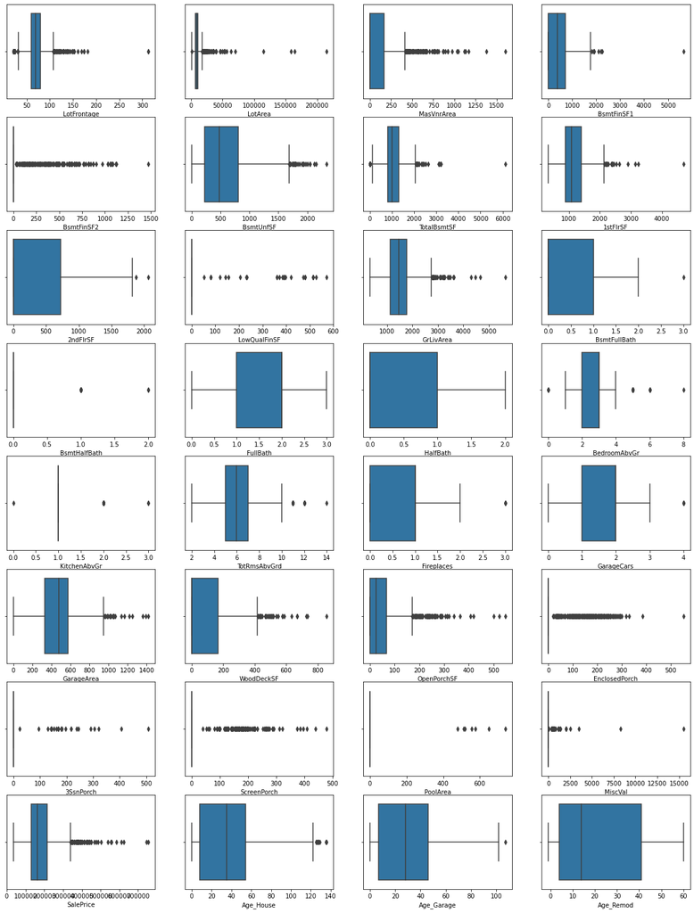

```python
plt.figure(figsize=(20,30))
for i in enumerate(numeric_cols):
    plt.subplot(9,4,i[0]+1)
    sns.boxplot(x=i[1], data=data)
```

```python
# as data row is just 1400 , so lets leave outlier check and will do cross validation for model to learn in better way...
```

```python
#lets check for salesprice outlier : target Variable

Q1 = data['SalePrice'].quantile(0.25)
Q3 = data['SalePrice'].quantile(0.75)
IQR = Q3-Q1
#data = data[(data['SalePrice'] >= Q1 - 1.5*IQR) &
 #                     (data['SalePrice'] <= Q3 + 1.5*IQR)]
data.shape
```

```
(1451, 79)
```

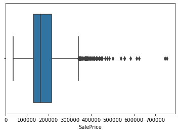

```python
sns.boxplot(data['SalePrice'])
```

# Categorical Features

```python
#get columns having columns having Object Dtype
category_cols = list(data.select_dtypes(include='object').columns)
```

```python
len(category_cols)
```

```
47
```

```python
#lets see value count for each columns
for col in category_cols:
    print('=========================================='+col+'================================================================')
    print(data[col].value_counts())
```

```
==========================================MSSubClass================================================================
20     532
60     296
50     144
120     86
30      69
160     63
70      60
80      57
90      52
190     30
85      20
75      16
45      12
180     10
40       4
Name: MSSubClass, dtype: int64
==========================================MSZoning================================================================
RL         1145
RM          218
FV           62
RH           16
C (all)      10
Name: MSZoning, dtype: int64
==========================================Street================================================================
Pave    1445
Grvl       6
Name: Street, dtype: int64
==========================================Alley================================================================
NO_Alley    1361
Grvl          50
Pave          40
Name: Alley, dtype: int64
==========================================LotShape================================================================
Reg    918
IR1    482
IR2     41
IR3     10
Name: LotShape, dtype: int64
==========================================LandContour================================================================
```

[output cut: 351 more lines]

```
ConLD       9
ConLw       5
ConLI       5
CWD         4
Oth         3
Con         2
Name: SaleType, dtype: int64
==========================================SaleCondition================================================================
Normal     1193
Partial     122
Abnorml     101
Family       20
Alloca       11
AdjLand       4
Name: SaleCondition, dtype: int64
```

```python
#replace col value which is less contributing that is any value less than 5% in that particular category will convert to other
def convertLessContributingColValuestoOther(category_cols):
    global data
    for col in category_cols:
        lessVarianceCol =[]
        data_var = round(100*(data[col].value_counts()/data.shape[0]),2).to_frame('Count')
        for i in data_var.index:
            if data_var.loc[i].Count < 5.00:
                lessVarianceCol.append(i)
        for col_val in lessVarianceCol:
            data = data.replace({col:{col_val:'Other'}})

        print("================"+col+"========================")
        print(data[col].value_counts())

#convertLessContributingColValuestoOther(category_cols)
#first have checked with this technique but droping this idea to revalidate the model without it.
```

```python
category_cols
```

```
['MSSubClass',
 'MSZoning',
 'Street',
 'Alley',
 'LotShape',
 'LandContour',
 'Utilities',
 'LotConfig',
 'LandSlope',
 'Neighborhood',
 'Condition1',
 'Condition2',
 'BldgType',
 'HouseStyle',
 'OverallQual',
 'OverallCond',
 'RoofStyle',
 'RoofMatl',
 'Exterior1st',
 'Exterior2nd',
 'MasVnrType',
 'ExterQual',
 'ExterCond',
 'Foundation',
 'BsmtQual',
 'BsmtCond',
 'BsmtExposure',
 'BsmtFinType1',
 'BsmtFinType2',
 'Heating',
 'HeatingQC',
 'CentralAir',
 'Electrical',
 'KitchenQual',
 'Functional',
 'FireplaceQu',
 'GarageType',
 'GarageFinish',
 'GarageQual',
 'GarageCond',
 'PavedDrive',
 'PoolQC',
 'Fence',
 'MiscFeature',
 'MoSold',
 'SaleType',
 'SaleCondition']
```

#### Convert Categorical variable into dummy columns

```python
#drop other column just formed as this is the combination of differnet cat value which is contributing very less
def dropOtherColValUsingOther(category_cols):
    global data
    for col in category_cols:
        try:
            temp_data = pd.get_dummies(data[col],prefix=col)
            temp_data = temp_data.drop(col+'_Other',axis=1)
            data = pd.concat([data,temp_data],axis=1)
            data = data.drop(col,axis=1)
        except:
            print(col)
            temp_data = pd.get_dummies(data[col],prefix=col,drop_first=True)
            data = pd.concat([data,temp_data],axis=1)
            data = data.drop(col,axis=1)


#dropOtherColVal(category_cols)
#dropping the idea to revalidate the model without it.
```

```python
def getDummy(category_cols):  # get dummy variable for the cate
    global data
    for col in category_cols:
            #print(col)
            temp_data = pd.get_dummies(data[col],prefix=col,drop_first=True)
            data = pd.concat([data,temp_data],axis=1)
            data = data.drop(col,axis=1)
```

```python
getDummy(category_cols)
```

```python
data.shape
```

```
(1451, 297)
```

```python
data.head()
```

|  | LotFrontage | LotArea | MasVnrArea | BsmtFinSF1 | BsmtFinSF2 | BsmtUnfSF | TotalBsmtSF | 1stFlrSF | 2ndFlrSF | LowQualFinSF | GrLivArea | BsmtFullBath | BsmtHalfBath | FullBath | HalfBath | BedroomAbvGr | KitchenAbvGr | TotRmsAbvGrd | Fireplaces | GarageCars | GarageArea | WoodDeckSF | OpenPorchSF | EnclosedPorch | 3SsnPorch | ScreenPorch | PoolArea | MiscVal | SalePrice | … |
| --- | --- | --- | --- | --- | --- | --- | --- | --- | --- | --- | --- | --- | --- | --- | --- | --- | --- | --- | --- | --- | --- | --- | --- | --- | --- | --- | --- | --- | --- | --- |
| 0 | 65.0 | 8450 | 196.0 | 706 | 0 | 150 | 856 | 856 | 854 | 0 | 1710 | 1 | 0 | 2 | 1 | 3 | 1 | 8 | 0 | 2 | 548 | 0 | 61 | 0 | 0 | 0 | 0 | 0 | 208500 | … |
| 1 | 80.0 | 9600 | 0.0 | 978 | 0 | 284 | 1262 | 1262 | 0 | 0 | 1262 | 0 | 1 | 2 | 0 | 3 | 1 | 6 | 1 | 2 | 460 | 298 | 0 | 0 | 0 | 0 | 0 | 0 | 181500 | … |
| 2 | 68.0 | 11250 | 162.0 | 486 | 0 | 434 | 920 | 920 | 866 | 0 | 1786 | 1 | 0 | 2 | 1 | 3 | 1 | 6 | 1 | 2 | 608 | 0 | 42 | 0 | 0 | 0 | 0 | 0 | 223500 | … |
| 3 | 60.0 | 9550 | 0.0 | 216 | 0 | 540 | 756 | 961 | 756 | 0 | 1717 | 1 | 0 | 1 | 0 | 3 | 1 | 7 | 1 | 3 | 642 | 0 | 35 | 272 | 0 | 0 | 0 | 0 | 140000 | … |
| 4 | 84.0 | 14260 | 350.0 | 655 | 0 | 490 | 1145 | 1145 | 1053 | 0 | 2198 | 1 | 0 | 2 | 1 | 4 | 1 | 9 | 1 | 3 | 836 | 192 | 84 | 0 | 0 | 0 | 0 | 0 | 250000 | … |

```python
#data shape now
data.shape
```

```
(1451, 297)
```

# So in total we have now with 297 Columns

#### Analysis about Target Variable

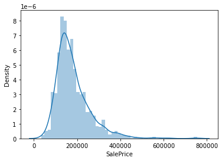

```python
#Target Variable distribution

sns.distplot(data['SalePrice'])
plt.show()
```

```python
#there is a Right skewness in data
data['SalePrice'].skew()
```

```
1.8831110462405252
```

# Modeling the data

```python
#import library
from sklearn.model_selection import train_test_split
from sklearn.preprocessing import MinMaxScaler
```

# Train Test Split

```python
df_train,df_test = train_test_split(data,train_size=0.8,test_size=0.2,random_state=100)
```

```python
print('Train Size ',df_train.shape)
print('Test Size ',df_test.shape)
```

```
Train Size  (1160, 297)
Test Size  (291, 297)
```

# Feature Scalling

```python
scaler = MinMaxScaler()
```

```python
# scaling for train data ( fit & tranform)
df_train[numeric_cols] = scaler.fit_transform(df_train[numeric_cols])
```

```python
len(numeric_cols) # it has all int64 & float64 dtype columns
```

```
32
```

```python
data.info()
```

```
<class 'pandas.core.frame.DataFrame'>
Int64Index: 1451 entries, 0 to 1459
Columns: 297 entries, LotFrontage to SaleCondition_Partial
dtypes: float64(3), int64(29), uint8(265)
memory usage: 749.6 KB
```

```python
# # scaling for test data ( transform)
df_test[numeric_cols] = scaler.transform(df_test[numeric_cols])
```

```python
df_train[numeric_cols].describe()
```

|  | LotFrontage | LotArea | MasVnrArea | BsmtFinSF1 | BsmtFinSF2 | BsmtUnfSF | TotalBsmtSF | 1stFlrSF | 2ndFlrSF | LowQualFinSF | GrLivArea | BsmtFullBath | BsmtHalfBath | FullBath | HalfBath | BedroomAbvGr | KitchenAbvGr | TotRmsAbvGrd | Fireplaces | GarageCars | GarageArea | WoodDeckSF | OpenPorchSF | EnclosedPorch | 3SsnPorch | ScreenPorch | PoolArea | MiscVal | SalePrice | … |
| --- | --- | --- | --- | --- | --- | --- | --- | --- | --- | --- | --- | --- | --- | --- | --- | --- | --- | --- | --- | --- | --- | --- | --- | --- | --- | --- | --- | --- | --- | --- |
| count | 1160.000000 | 1160.000000 | 1160.000000 | 1160.000000 | 1160.000000 | 1160.000000 | 1160.000000 | 1160.000000 | 1160.000000 | 1160.000000 | 1160.000000 | 1160.000000 | 1160.000000 | 1160.000000 | 1160.000000 | 1160.000000 | 1160.000000 | 1160.000000 | 1160.000000 | 1160.000000 | 1160.000000 | 1160.000000 | 1160.000000 | 1160.000000 | 1160.000000 | 1160.000000 | 1160.000000 | 1160.000000 | 1160.000000 | … |
| mean | 0.167357 | 0.043276 | 0.065932 | 0.078090 | 0.041857 | 0.246691 | 0.174122 | 0.182898 | 0.169176 | 0.010747 | 0.207458 | 0.141092 | 0.027586 | 0.521839 | 0.190086 | 0.357328 | 0.348276 | 0.317555 | 0.203448 | 0.441379 | 0.333992 | 0.107453 | 0.087469 | 0.040156 | 0.007662 | 0.032935 | 0.004032 | 0.002794 | 0.203039 | … |
| std | 0.076993 | 0.049920 | 0.116217 | 0.081836 | 0.144454 | 0.190020 | 0.072675 | 0.091215 | 0.212069 | 0.085665 | 0.103623 | 0.173824 | 0.116081 | 0.181869 | 0.248960 | 0.101010 | 0.073054 | 0.149012 | 0.215379 | 0.186097 | 0.152098 | 0.143445 | 0.125691 | 0.111443 | 0.062925 | 0.120877 | 0.056628 | 0.031899 | 0.110910 | … |
| min | 0.000000 | 0.000000 | 0.000000 | 0.000000 | 0.000000 | 0.000000 | 0.000000 | 0.000000 | 0.000000 | 0.000000 | 0.000000 | 0.000000 | 0.000000 | 0.000000 | 0.000000 | 0.000000 | 0.000000 | 0.000000 | 0.000000 | 0.000000 | 0.000000 | 0.000000 | 0.000000 | 0.000000 | 0.000000 | 0.000000 | 0.000000 | 0.000000 | 0.000000 | … |
| 25% | 0.133562 | 0.028979 | 0.000000 | 0.000000 | 0.000000 | 0.096961 | 0.130728 | 0.118056 | 0.000000 | 0.000000 | 0.130669 | 0.000000 | 0.000000 | 0.333333 | 0.000000 | 0.250000 | 0.333333 | 0.181818 | 0.000000 | 0.250000 | 0.236953 | 0.000000 | 0.000000 | 0.000000 | 0.000000 | 0.000000 | 0.000000 | 0.000000 | 0.131371 | … |
| 50% | 0.164384 | 0.038134 | 0.000000 | 0.066442 | 0.000000 | 0.208690 | 0.162439 | 0.163773 | 0.000000 | 0.000000 | 0.195619 | 0.000000 | 0.000000 | 0.666667 | 0.000000 | 0.375000 | 0.333333 | 0.272727 | 0.333333 | 0.500000 | 0.338505 | 0.000000 | 0.045704 | 0.000000 | 0.000000 | 0.000000 | 0.000000 | 0.000000 | 0.177753 | … |
| 75% | 0.198630 | 0.048087 | 0.105625 | 0.124956 | 0.000000 | 0.349315 | 0.212398 | 0.235880 | 0.353148 | 0.000000 | 0.259896 | 0.333333 | 0.000000 | 0.666667 | 0.500000 | 0.375000 | 0.333333 | 0.363636 | 0.333333 | 0.500000 | 0.406206 | 0.196033 | 0.127971 | 0.000000 | 0.000000 | 0.000000 | 0.000000 | 0.000000 | 0.250104 | … |
| max | 1.000000 | 1.000000 | 1.000000 | 1.000000 | 1.000000 | 1.000000 | 1.000000 | 1.000000 | 1.000000 | 1.000000 | 1.000000 | 1.000000 | 1.000000 | 1.000000 | 1.000000 | 1.000000 | 1.000000 | 1.000000 | 1.000000 | 1.000000 | 1.000000 | 1.000000 | 1.000000 | 1.000000 | 1.000000 | 1.000000 | 1.000000 | 1.000000 | 1.000000 | … |

#### Correlation Check :HeatMap

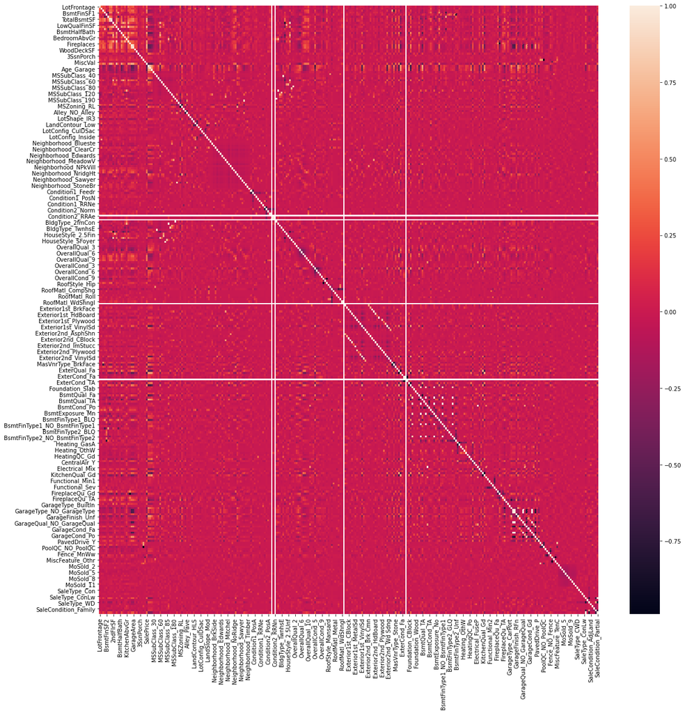

```python
plt.figure(figsize=(20,20))
sns.heatmap(df_train.corr())
```

```python
corr = df_train.corr().abs()
corr_stack = corr.unstack()
corr_stack = corr_stack.sort_values(kind='quicksort',ascending=False)
df_corr = pd.DataFrame(corr_stack)
```

```python
#print highly Negatively correlated columns
print(df_corr[(df_corr[0]>-1 )& (df_corr[0]<-0.7)])
```

```
Empty DataFrame
Columns: [0]
Index: []
```

```python
#print highly Positively correlated columns
print(df_corr[(df_corr[0]<1 )& (df_corr[0]>0.7)])
```

```
                                                                  0
SaleType_New                 SaleCondition_Partial         0.988263
SaleCondition_Partial        SaleType_New                  0.988263
PoolArea                     PoolQC_NO_PoolQC              0.987966
PoolQC_NO_PoolQC             PoolArea                      0.987966
BsmtFinType2_NO_BsmtFinType2 BsmtCond_NO_BsmtCond          0.980149
...                                                             ...
GarageQual_TA                GarageFinish_NO_GarageFinish  0.703011
GarageCond_NO_GarageCond     GarageQual_TA                 0.703011
GarageQual_TA                GarageQual_NO_GarageQual      0.703011
                             GarageCond_NO_GarageCond      0.703011
GarageFinish_NO_GarageFinish GarageQual_TA                 0.703011

[124 rows x 1 columns]
```

```python
#select one of the column of highly correlated pair, droping this will help odel to learn better
selected_col_list=[]
not_selected_col_list =[]
for index in df_corr[(df_corr[0]<1 )& (df_corr[0]>0.7)].index:
    if index[0] not in not_selected_col_list:
        selected_col_list.append(str(index[0]))
    not_selected_col_list.append(index[1])
```

```python
selected_col_list
```

```
['SaleType_New',
 'PoolArea',
 'BsmtFinType2_NO_BsmtFinType2',
 'BsmtExposure_NO_BsmtExposure',
 'Exterior2nd_CmentBd',
 'BldgType_2fmCon',
 'Exterior1st_VinylSd',
 'Exterior2nd_MetalSd',
 'MiscFeature_Shed',
 'HouseStyle_SLvl',
 'RoofStyle_Hip',
 'MSSubClass_45',
 'ExterCond_Gd',
 'ExterQual_Gd',
 'FireplaceQu_NO_FireplaceQu',
 'GarageArea',
 'Exterior2nd_HdBoard',
 'Exterior2nd_Wd Sdng',
 'Neighborhood_Somerst',
 '1stFlrSF',
 'KitchenQual_TA',
 'MSZoning_RM',
 'TotRmsAbvGrd',
 '2ndFlrSF',
 'MasVnrType_BrkFace',
 'GarageCond_TA',
 'Foundation_CBlock',
 'HouseStyle_1Story',
 'MSSubClass_120',
 'BsmtQual_Gd',
 'Age_House',
 'MSSubClass_60',
 'Exterior1st_Stucco',
 'Heating_GasW',
 'Exterior2nd_Plywood',
 'GarageCond_NO_GarageCond',
 'GarageQual_NO_GarageQual',
 'BsmtFinType2_Unf',
 'GarageType_Attchd',
 'HouseStyle_SFoyer',
 'Fence_MnPrv',
 'PoolQC_Fa',
 'Condition2_Feedr']
```

```python
#drop highly correlated columns which is in selected_col_list from both test & train data
#for col in selected_col_list:
df_train = df_train.drop(selected_col_list,axis=1)
df_test = df_test.drop(selected_col_list,axis=1)
```

```python
df_train.shape
```

```
(1160, 254)
```

```python
df_test.shape
```

```
(291, 254)
```

# Create X_train, y_train

```python
y_train = df_train.pop('SalePrice')
x_train = df_train
```

```python
del df_train
```

```python
x_train.head()
```

|  | LotFrontage | LotArea | MasVnrArea | BsmtFinSF1 | BsmtFinSF2 | BsmtUnfSF | TotalBsmtSF | LowQualFinSF | GrLivArea | BsmtFullBath | BsmtHalfBath | FullBath | HalfBath | BedroomAbvGr | KitchenAbvGr | Fireplaces | GarageCars | WoodDeckSF | OpenPorchSF | EnclosedPorch | 3SsnPorch | ScreenPorch | MiscVal | Age_Garage | Age_Remod | MSSubClass_30 | MSSubClass_40 | MSSubClass_50 | MSSubClass_70 | … |
| --- | --- | --- | --- | --- | --- | --- | --- | --- | --- | --- | --- | --- | --- | --- | --- | --- | --- | --- | --- | --- | --- | --- | --- | --- | --- | --- | --- | --- | --- | --- |
| 624 | 0.202055 | 0.042534 | 0.180 | 0.043763 | 0.0 | 0.207620 | 0.119804 | 0.0 | 0.259800 | 0.333333 | 0.0 | 0.333333 | 1.0 | 0.500 | 0.333333 | 0.333333 | 0.50 | 0.172695 | 0.000000 | 0.000000 | 0.0 | 0.30625 | 0.0 | 0.317757 | 0.573770 | 0 | 0 | 0 | 0 | … |
| 592 | 0.133562 | 0.024773 | 0.000 | 0.144578 | 0.0 | 0.000000 | 0.133552 | 0.0 | 0.072636 | 0.333333 | 0.0 | 0.333333 | 0.0 | 0.250 | 0.333333 | 0.000000 | 0.50 | 0.000000 | 0.000000 | 0.000000 | 0.0 | 0.00000 | 0.0 | 0.214953 | 0.098361 | 0 | 0 | 0 | 0 | … |
| 48 | 0.041096 | 0.014751 | 0.000 | 0.000000 | 0.0 | 0.315068 | 0.120458 | 0.0 | 0.194850 | 0.000000 | 0.0 | 0.666667 | 0.0 | 0.250 | 1.000000 | 0.000000 | 0.00 | 0.000000 | 0.000000 | 0.184783 | 0.0 | 0.00000 | 0.0 | 0.271028 | 0.032787 | 0 | 0 | 0 | 0 | … |
| 1070 | 0.174658 | 0.041375 | 0.075 | 0.103827 | 0.0 | 0.197774 | 0.171522 | 0.0 | 0.117218 | 0.333333 | 0.0 | 0.333333 | 0.0 | 0.375 | 0.333333 | 0.000000 | 0.25 | 0.000000 | 0.036563 | 0.000000 | 0.0 | 0.40000 | 0.0 | 0.476636 | 0.852459 | 0 | 0 | 0 | 0 | … |
| 1234 | 0.116438 | 0.033770 | 0.000 | 0.000000 | 0.0 | 0.402397 | 0.153846 | 0.0 | 0.293236 | 0.000000 | 0.0 | 0.333333 | 0.5 | 0.500 | 0.333333 | 0.000000 | 0.00 | 0.000000 | 0.351005 | 0.000000 | 0.0 | 0.00000 | 0.0 | 0.261682 | 0.967213 | 0 | 0 | 0 | 1 | … |

```python
y_train.head()
```

```
624     0.180878
592     0.143175
48      0.108457
1070    0.139008
1234    0.132065
Name: SalePrice, dtype: float64
```

# x_test & y_test

```python
y_test = df_test.pop('SalePrice')
x_test = df_test
```

```python
# delete df_test
del df_test
```

# Normal Regression without Regularisation

```python
from sklearn.linear_model import LinearRegression
import sklearn.metrics as metrics
```

```python
y_train
```

```
624     0.180878
592     0.143175
48      0.108457
1070    0.139008
1234    0.132065
          ...
805     0.267713
53      0.486182
351     0.215387
79      0.104291
795     0.189002
Name: SalePrice, Length: 1160, dtype: float64
```

```python
x_train.head()
```

|  | LotFrontage | LotArea | MasVnrArea | BsmtFinSF1 | BsmtFinSF2 | BsmtUnfSF | TotalBsmtSF | LowQualFinSF | GrLivArea | BsmtFullBath | BsmtHalfBath | FullBath | HalfBath | BedroomAbvGr | KitchenAbvGr | Fireplaces | GarageCars | WoodDeckSF | OpenPorchSF | EnclosedPorch | 3SsnPorch | ScreenPorch | MiscVal | Age_Garage | Age_Remod | MSSubClass_30 | MSSubClass_40 | MSSubClass_50 | MSSubClass_70 | … |
| --- | --- | --- | --- | --- | --- | --- | --- | --- | --- | --- | --- | --- | --- | --- | --- | --- | --- | --- | --- | --- | --- | --- | --- | --- | --- | --- | --- | --- | --- | --- |
| 624 | 0.202055 | 0.042534 | 0.180 | 0.043763 | 0.0 | 0.207620 | 0.119804 | 0.0 | 0.259800 | 0.333333 | 0.0 | 0.333333 | 1.0 | 0.500 | 0.333333 | 0.333333 | 0.50 | 0.172695 | 0.000000 | 0.000000 | 0.0 | 0.30625 | 0.0 | 0.317757 | 0.573770 | 0 | 0 | 0 | 0 | … |
| 592 | 0.133562 | 0.024773 | 0.000 | 0.144578 | 0.0 | 0.000000 | 0.133552 | 0.0 | 0.072636 | 0.333333 | 0.0 | 0.333333 | 0.0 | 0.250 | 0.333333 | 0.000000 | 0.50 | 0.000000 | 0.000000 | 0.000000 | 0.0 | 0.00000 | 0.0 | 0.214953 | 0.098361 | 0 | 0 | 0 | 0 | … |
| 48 | 0.041096 | 0.014751 | 0.000 | 0.000000 | 0.0 | 0.315068 | 0.120458 | 0.0 | 0.194850 | 0.000000 | 0.0 | 0.666667 | 0.0 | 0.250 | 1.000000 | 0.000000 | 0.00 | 0.000000 | 0.000000 | 0.184783 | 0.0 | 0.00000 | 0.0 | 0.271028 | 0.032787 | 0 | 0 | 0 | 0 | … |
| 1070 | 0.174658 | 0.041375 | 0.075 | 0.103827 | 0.0 | 0.197774 | 0.171522 | 0.0 | 0.117218 | 0.333333 | 0.0 | 0.333333 | 0.0 | 0.375 | 0.333333 | 0.000000 | 0.25 | 0.000000 | 0.036563 | 0.000000 | 0.0 | 0.40000 | 0.0 | 0.476636 | 0.852459 | 0 | 0 | 0 | 0 | … |
| 1234 | 0.116438 | 0.033770 | 0.000 | 0.000000 | 0.0 | 0.402397 | 0.153846 | 0.0 | 0.293236 | 0.000000 | 0.0 | 0.333333 | 0.5 | 0.500 | 0.333333 | 0.000000 | 0.00 | 0.000000 | 0.351005 | 0.000000 | 0.0 | 0.00000 | 0.0 | 0.261682 | 0.967213 | 0 | 0 | 0 | 1 | … |

```python
lm = LinearRegression()
```

```python
# fit the model on the x_train & y_train
lm.fit(x_train,y_train)
```

```
LinearRegression()
```

```python
#predict the data
y_train_pred = lm.predict(x_train)
```

```python
#r2 score on train data
metrics.r2_score(y_true=y_train,y_pred=y_train_pred)
```

```
0.9362264778189486
```

```python
#fit model to test data
y_test_pred = lm.predict(x_test)
```

```python
#r2 score on test data
metrics.r2_score(y_true=y_test,y_pred=y_test_pred)
```

```
-3.0526800368359716e+20
```

# Without Regularization model is performing Overfitting as train score is high & test score is very less, so lets re model using regularization

```python
#model interecept & coefficent
model_params = lm.coef_

cols = x_train.columns
cols = cols.insert(0,"constant")
list(zip(cols,model_params))
```

```
[('constant', 0.033871195717428096),
 ('LotFrontage', 0.18090895118194028),
 ('LotArea', 0.051946590254517),
 ('MasVnrArea', 61194830730.994095),
 ('BsmtFinSF1', 12143552519.259005),
 ('BsmtFinSF2', 25327980968.67968),
 ('BsmtUnfSF', -66247415975.33518),
 ('TotalBsmtSF', -0.047914788275535684),
 ('LowQualFinSF', 0.39907016113972515),
 ('GrLivArea', 0.009182333946228027),
 ('BsmtFullBath', 0.005195140838623047),
 ('BsmtHalfBath', 0.024549484252929688),
 ('FullBath', 0.00701904296875),
 ('HalfBath', -0.0177764892578125),
 ('BedroomAbvGr', -0.07386589050292969),
 ('KitchenAbvGr', 0.011922836303710938),
 ('Fireplaces', 0.036945343017578125),
 ('GarageCars', 0.008175373077392578),
 ('WoodDeckSF', 0.00226593017578125),
 ('OpenPorchSF', 0.003471851348876953),
 ('EnclosedPorch', 0.03962588310241699),
 ('3SsnPorch', 0.022725343704223633),
 ('ScreenPorch', 0.008626103401184082),
 ('MiscVal', -0.012192726135253906),
 ('Age_Garage', -0.01104736328125),
 ('Age_Remod', -0.0039958953857421875),
 ('MSSubClass_30', -0.0036468505859375),
 ('MSSubClass_40', -0.008066177368164062),
 ('MSSubClass_50', -0.0071642398834228516),
 ('MSSubClass_70', -0.030344486236572266),
 ('MSSubClass_75', -0.0003452301025390625),
 ('MSSubClass_80', -0.007532358169555664),
 ('MSSubClass_85', -31784011492.6428),
 ('MSSubClass_90', -0.0048618316650390625),
 ('MSSubClass_160', 0.007254123687744141),
 ('MSSubClass_180', -0.0168914794921875),
 ('MSSubClass_190', 0.015295028686523438),
 ('MSZoning_FV', 0.011292099952697754),
 ('MSZoning_RH', 0.006561279296875),
 ('MSZoning_RL', 0.051470279693603516),
```

[output cut: 198 more lines]

```
 ('MoSold_9', -0.0083770751953125),
 ('MoSold_10', -0.004036903381347656),
 ('MoSold_11', 0.00177001953125),
 ('MoSold_12', 0.010992050170898438),
 ('SaleType_CWD', 0.04285264015197754),
 ('SaleType_Con', 0.014758944511413574),
 ('SaleType_ConLD', 0.0005900859832763672),
 ('SaleType_ConLI', 0.012084484100341797),
 ('SaleType_ConLw', 0.02588057518005371),
 ('SaleType_Oth', 0.002834320068359375),
 ('SaleType_WD', 0.02011662721633911),
 ('SaleCondition_AdjLand', 0.012341022491455078),
 ('SaleCondition_Alloca', 0.008935213088989258),
 ('SaleCondition_Family', 0.0126495361328125),
 ('SaleCondition_Normal', 0.0402679443359375)]
```

# Ridge Regression

```python
from sklearn.model_selection import KFold
from sklearn.model_selection import GridSearchCV
from sklearn.linear_model import Ridge
```

```python
params = {'alpha':[0.0001, 0.001, 0.01, 0.05, 0.1,
 0.2, 0.3, 0.4, 0.5, 0.6, 0.7, 0.8, 0.9, 1.0, 2.0, 3.0,
 4.0, 5.0, 6.0, 7.0, 8.0, 9.0, 10.0, 20, 50, 100, 500, 1000]}

ridge= Ridge()
```

```python
# five fold Grid Search cross validation
folds= 5

model_cv = GridSearchCV(estimator=ridge,
                       param_grid=params,
                       scoring='r2',
                       cv=folds,
                       return_train_score=True,
                       verbose=1)

model_cv.fit(x_train,y_train)
```

```
Fitting 5 folds for each of 28 candidates, totalling 140 fits
```

```
GridSearchCV(cv=5, estimator=Ridge(),
             param_grid={'alpha': [0.0001, 0.001, 0.01, 0.05, 0.1, 0.2, 0.3,
                                   0.4, 0.5, 0.6, 0.7, 0.8, 0.9, 1.0, 2.0, 3.0,
                                   4.0, 5.0, 6.0, 7.0, 8.0, 9.0, 10.0, 20, 50,
                                   100, 500, 1000]},
             return_train_score=True, scoring='r2', verbose=1)
```

# Optimal Lambda

```python
#checking the value of optimum number of parameters
print(model_cv.best_params_)
print(model_cv.best_score_)
```

```
{'alpha': 10.0}
0.8003792977747926
```

```python
#result of cross validation
ridge_results = pd.DataFrame(model_cv.cv_results_)
ridge_results.head()
```

|  | mean_fit_time | std_fit_time | mean_score_time | std_score_time | param_alpha | params | split0_test_score | split1_test_score | split2_test_score | split3_test_score | split4_test_score | mean_test_score | std_test_score | rank_test_score | split0_train_score | split1_train_score | split2_train_score | split3_train_score | split4_train_score | mean_train_score | std_train_score |
| --- | --- | --- | --- | --- | --- | --- | --- | --- | --- | --- | --- | --- | --- | --- | --- | --- | --- | --- | --- | --- | --- |
| 0 | 0.018000 | 0.001673 | 0.006601 | 0.000801 | 0.0001 | {'alpha': 0.0001} | 0.386908 | 0.120228 | 0.587347 | 0.583196 | 0.819890 | 0.499514 | 0.234049 | 27 | 0.950658 | 0.950252 | 0.935854 | 0.938345 | 0.943398 | 0.943701 | 0.006028 |
| 1 | 0.018602 | 0.001358 | 0.007198 | 0.000747 | 0.001 | {'alpha': 0.001} | 0.409076 | 0.120727 | 0.604896 | 0.584678 | 0.819693 | 0.507814 | 0.233318 | 26 | 0.950638 | 0.950252 | 0.935838 | 0.938345 | 0.943376 | 0.943690 | 0.006027 |
| 2 | 0.020001 | 0.003164 | 0.007062 | 0.001046 | 0.01 | {'alpha': 0.01} | 0.555133 | 0.125618 | 0.719973 | 0.598773 | 0.817017 | 0.563303 | 0.237407 | 25 | 0.949390 | 0.950247 | 0.934879 | 0.938316 | 0.942134 | 0.942993 | 0.006033 |
| 3 | 0.021001 | 0.001412 | 0.008599 | 0.000491 | 0.05 | {'alpha': 0.05} | 0.731662 | 0.145530 | 0.846699 | 0.648588 | 0.811163 | 0.636728 | 0.254929 | 23 | 0.942246 | 0.950155 | 0.929517 | 0.937787 | 0.936215 | 0.939184 | 0.006840 |
| 4 | 0.018603 | 0.001623 | 0.007397 | 0.001354 | 0.1 | {'alpha': 0.1} | 0.775974 | 0.167127 | 0.871079 | 0.691191 | 0.812244 | 0.663523 | 0.254958 | 22 | 0.937157 | 0.949933 | 0.925806 | 0.936643 | 0.932551 | 0.936418 | 0.007884 |

```python
ridge_results['param_alpha'] = ridge_results['param_alpha'].astype('int32')
```

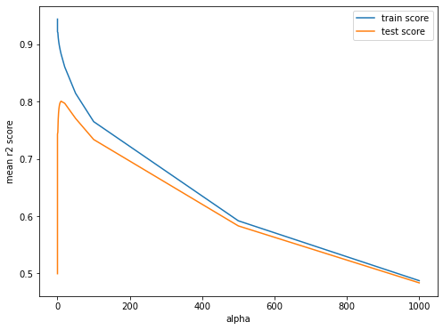

```python
#plot of mean r2 vs lambda value
plt.figure(figsize=(8,6))

plt.plot(ridge_results['param_alpha'],ridge_results['mean_train_score'])
plt.plot(ridge_results['param_alpha'],ridge_results['mean_test_score'])
plt.legend(['train score','test score'])
plt.xlabel('alpha')
plt.ylabel('mean r2 score')
plt.show()
```

# Analysis of the above graph

#### As the alpha (lambda) increases, the r2 score decreases. That means the error increases. Because the model becomes less overfitting and more generalised. Thus by increasing the alpha the model becomes more simple.

# Test Score

With the very lower value of alpha, the error is high as we can see the r2 value decreased. But the error for the train set is low. It means that the model is clearly overfitting with very low value of alpha. With the increasing value of alpha, the error started decreasing more and it reached to a peak at alpha=10. Here, the error is least and accuracy (r2 score) is the highest. After alpha=10, the r2 score started decreasing as the alpha is increasing. Hence, the model accuracy started dipping. We need to pick the value of aplha for which the test score peaks up.

## So, the optimum alpha will be 10, for which we will have a right balance between the error and the generalisation of the model for creting a simpler model.

## Train ( .87) & test (.85) accuracy ( measured in terms of r2) is good

```python
#model for optimum alpha : model_cv.best_params_['alpha']
model_ridge = Ridge(alpha=model_cv.best_params_['alpha'])

model_ridge.fit(x_train,y_train)
```

```
Ridge(alpha=10.0)
```

```python
# metric for train model
y_train_pred = model_ridge.predict(x_train)
print(metrics.r2_score(y_true=y_train,y_pred=y_train_pred))
```

```
0.8797091570831795
```

```python
#metric for test model
y_test_pred = model_ridge.predict(x_test)
print(metrics.r2_score(y_true=y_test,y_pred=y_test_pred))
```

```
0.8597178436196702
```

# Conclusion

We have a good train score 87% and good test score as well 85%. That means what the model learnt in the train set it performed well in the test set.

```python
#model coefficent & intercept
model_ridge_param = list(model_ridge.coef_)

model_ridge_param.insert(0,model_ridge.intercept_)
model_ridge_param = [round(i,3) for i in model_ridge_param]

cols = x_train.columns
cols = cols.insert(0,'constant')
ridge_param_list = list(zip(cols,model_ridge_param))
ridge_param_list
```

```
[('constant', 0.107),
 ('LotFrontage', 0.008),
 ('LotArea', 0.02),
 ('MasVnrArea', 0.04),
 ('BsmtFinSF1', 0.024),
 ('BsmtFinSF2', 0.008),
 ('BsmtUnfSF', 0.018),
 ('TotalBsmtSF', 0.031),
 ('LowQualFinSF', 0.002),
 ('GrLivArea', 0.086),
 ('BsmtFullBath', 0.023),
 ('BsmtHalfBath', 0.006),
 ('FullBath', 0.06),
 ('HalfBath', 0.024),
 ('BedroomAbvGr', 0.027),
 ('KitchenAbvGr', -0.006),
 ('Fireplaces', 0.034),
 ('GarageCars', 0.058),
 ('WoodDeckSF', 0.022),
 ('OpenPorchSF', 0.009),
 ('EnclosedPorch', 0.006),
 ('3SsnPorch', 0.012),
 ('ScreenPorch', 0.015),
 ('MiscVal', 0.001),
 ('Age_Garage', -0.003),
 ('Age_Remod', -0.019),
 ('MSSubClass_30', -0.01),
 ('MSSubClass_40', 0.003),
 ('MSSubClass_50', 0.006),
 ('MSSubClass_70', 0.007),
 ('MSSubClass_75', 0.01),
 ('MSSubClass_80', -0.006),
 ('MSSubClass_85', -0.011),
 ('MSSubClass_90', -0.007),
 ('MSSubClass_160', -0.015),
 ('MSSubClass_180', -0.008),
 ('MSSubClass_190', -0.008),
 ('MSZoning_FV', 0.012),
 ('MSZoning_RH', 0.008),
 ('MSZoning_RL', 0.009),
```

[output cut: 199 more lines]

```
 ('MoSold_10', -0.006),
 ('MoSold_11', 0.001),
 ('MoSold_12', -0.002),
 ('SaleType_CWD', 0.004),
 ('SaleType_Con', 0.005),
 ('SaleType_ConLD', 0.0),
 ('SaleType_ConLI', 0.004),
 ('SaleType_ConLw', -0.0),
 ('SaleType_Oth', -0.0),
 ('SaleType_WD', -0.007),
 ('SaleCondition_AdjLand', 0.002),
 ('SaleCondition_Alloca', 0.009),
 ('SaleCondition_Family', 0.003),
 ('SaleCondition_Normal', 0.005),
 ('SaleCondition_Partial', 0.017)]
```

# Top 10 feature of Ridge Regression

```python
ridge_params_df = pd.DataFrame({'Params':cols,'Coef':model_ridge_param})
(ridge_params_df.sort_values('Coef',ascending=False)).head(11)
```

|  | Params | Coef |
| --- | --- | --- |
| 0 | constant | 0.107 |
| 9 | GrLivArea | 0.086 |
| 108 | OverallQual_10 | 0.076 |
| 107 | OverallQual_9 | 0.069 |
| 12 | FullBath | 0.060 |
| 17 | GarageCars | 0.058 |
| 70 | Neighborhood_NoRidge | 0.051 |
| 127 | RoofMatl_WdShngl | 0.046 |
| 3 | MasVnrArea | 0.040 |
| 76 | Neighborhood_StoneBr | 0.034 |
| 16 | Fireplaces | 0.034 |

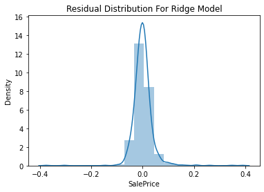

```python
res = y_train - y_train_pred
sns.distplot(res,bins=20)
plt.title('Residual Distribution For Ridge Model')
plt.show()
```

```python
#linear regression assumption hold correct : error is normally distributted
```

# Lasso Regression

```python
#to answer subjective question, rmoving 5 most imp feature
#x_train.drop(['GrLivArea','OverallQual_9','OverallQual_10','GarageCars','Neighborhood_NoRidge'],axis=1,inplace=True)
#x_test.drop(['GrLivArea','OverallQual_9','OverallQual_10','GarageCars','Neighborhood_NoRidge'],axis=1,inplace=True)
```

```python
#import lasso
from sklearn.linear_model import Lasso
```

```python
# different value of lambda: already defined in ridge section as well
#params = params = {'alpha':[0.0001, 0.001, 0.01, 0.05, 0.1,0.2, 0.3, 0.4, 0.5, 0.6, 0.7, 0.8, 0.9, 1.0, 2.0, 3.0,
# 4.0, 5.0, 6.0, 7.0, 8.0, 9.0, 10.0, 20, 50, 100, 500, 1000]}
```

```python
#init lasso
lasso = Lasso()
```

```python
# five fold cross validation & r2 score as estimator
model_cv = GridSearchCV(estimator=lasso,
                       param_grid=params,
                       scoring='r2',
                       cv=folds,
                       return_train_score=True,
                       verbose=1)

model_cv.fit(x_train,y_train)
```

```
Fitting 5 folds for each of 28 candidates, totalling 140 fits
```

```
GridSearchCV(cv=5, estimator=Lasso(),
             param_grid={'alpha': [0.0001, 0.001, 0.01, 0.05, 0.1, 0.2, 0.3,
                                   0.4, 0.5, 0.6, 0.7, 0.8, 0.9, 1.0, 2.0, 3.0,
                                   4.0, 5.0, 6.0, 7.0, 8.0, 9.0, 10.0, 20, 50,
                                   100, 500, 1000]},
             return_train_score=True, scoring='r2', verbose=1)
```

# Optimal Lambda

```python
#checking the value of optimum number of parameters
print(model_cv.best_params_)
print(model_cv.best_score_)
```

```
{'alpha': 0.001}
0.7819785830922694
```

```python
# creating dataframe with model_cv results
lasso_results = pd.DataFrame(model_cv.cv_results_)
lasso_results.head()
```

|  | mean_fit_time | std_fit_time | mean_score_time | std_score_time | param_alpha | params | split0_test_score | split1_test_score | split2_test_score | split3_test_score | split4_test_score | mean_test_score | std_test_score | rank_test_score | split0_train_score | split1_train_score | split2_train_score | split3_train_score | split4_train_score | mean_train_score | std_train_score |
| --- | --- | --- | --- | --- | --- | --- | --- | --- | --- | --- | --- | --- | --- | --- | --- | --- | --- | --- | --- | --- | --- |
| 0 | 0.040800 | 0.012782 | 0.005999 | 0.000633 | 0.0001 | {'alpha': 0.0001} | 0.824626 | 0.336167 | 0.895969 | 0.686402 | 0.834677 | 0.715568 | 0.201703 | 2 | 0.912037 | 0.939195 | 0.904496 | 0.925846 | 0.910840 | 0.918483 | 0.012480 |
| 1 | 0.015998 | 0.000895 | 0.005201 | 0.000750 | 0.001 | {'alpha': 0.001} | 0.752132 | 0.609874 | 0.886491 | 0.844553 | 0.816844 | 0.781979 | 0.096504 | 1 | 0.826002 | 0.877035 | 0.818237 | 0.827083 | 0.826166 | 0.834905 | 0.021305 |
| 2 | 0.012200 | 0.001599 | 0.004200 | 0.000400 | 0.01 | {'alpha': 0.01} | 0.320514 | 0.427547 | 0.396287 | 0.404422 | 0.355871 | 0.380928 | 0.038050 | 3 | 0.407152 | 0.377727 | 0.374122 | 0.382717 | 0.380355 | 0.384414 | 0.011722 |
| 3 | 0.015068 | 0.001512 | 0.005398 | 0.000490 | 0.05 | {'alpha': 0.05} | -0.000160 | -0.000443 | -0.000861 | -0.001868 | -0.004132 | -0.001493 | 0.001441 | 4 | 0.000000 | 0.000000 | 0.000000 | 0.000000 | 0.000000 | 0.000000 | 0.000000 |
| 4 | 0.014401 | 0.001020 | 0.006000 | 0.001096 | 0.1 | {'alpha': 0.1} | -0.000160 | -0.000443 | -0.000861 | -0.001868 | -0.004132 | -0.001493 | 0.001441 | 4 | 0.000000 | 0.000000 | 0.000000 | 0.000000 | 0.000000 | 0.000000 | 0.000000 |

```python
lasso_results['param_alpha'] = lasso_results['param_alpha'].astype('float32')
```

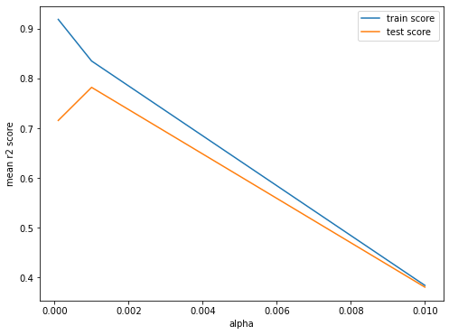

```python
#plot graph for train /test score vs mean r2 score around optimal lambda 0.0001
plt.figure(figsize=(8,6))
plt.plot(lasso_results[lasso_results['param_alpha']<=0.01]['param_alpha'],lasso_results[lasso_results['param_alpha']<=0.01]['mean_train_score'])
plt.plot(lasso_results[lasso_results['param_alpha']<=0.01]['param_alpha'],lasso_results[lasso_results['param_alpha']<=0.01]['mean_test_score'])

plt.legend(['train score','test score'])
plt.xlabel('alpha')
plt.ylabel('mean r2 score')
plt.show()
```

### Analysis of the above graph

Train Score : 83%

Test Score : 81%

So, the optimum alpha will be 0.001, for which we will have a right balance between the error and the generalisation of the model for creating a simpler model.

```python
#lasso with alpha 0.001

model_lasso = Lasso((model_cv.best_params_['alpha']))

model_lasso.fit(x_train,y_train)
```

```
Lasso(alpha=0.001)
```

```python
# model evaluation in train set
y_train_pred = model_lasso.predict(x_train)
print(metrics.r2_score(y_train,y_pred=y_train_pred))
```

```
0.8308100698539118
```

```python
# Model evaluation on test set
y_test_pred = model_lasso.predict(x_test)
print(metrics.r2_score(y_true=y_test,y_pred=y_test_pred))
```

```
0.8176168814232624
```

### We have train set accuracy 83% whereas test set accuracy is 81%. From the accuracy gap, we can conclude that what the model learnt on the train set, it performed well on the test set.

```python
model_lasso_param = list(model_lasso.coef_)

model_lasso_param.insert(0,model_lasso.intercept_)

model_lasso_param = [round(i,3) for i in model_lasso_param]

cols = x_train.columns
cols = cols.insert(0,'constant')
lasso_param_list = list(zip(cols,model_lasso_param))
lasso_param_list
```

```
[('constant', 0.086),
 ('LotFrontage', 0.0),
 ('LotArea', 0.0),
 ('MasVnrArea', 0.0),
 ('BsmtFinSF1', 0.0),
 ('BsmtFinSF2', 0.0),
 ('BsmtUnfSF', 0.0),
 ('TotalBsmtSF', 0.0),
 ('LowQualFinSF', -0.0),
 ('GrLivArea', 0.261),
 ('BsmtFullBath', 0.0),
 ('BsmtHalfBath', 0.0),
 ('FullBath', 0.016),
 ('HalfBath', 0.002),
 ('BedroomAbvGr', 0.0),
 ('KitchenAbvGr', -0.0),
 ('Fireplaces', 0.038),
 ('GarageCars', 0.083),
 ('WoodDeckSF', 0.0),
 ('OpenPorchSF', 0.0),
 ('EnclosedPorch', -0.0),
 ('3SsnPorch', 0.0),
 ('ScreenPorch', 0.0),
 ('MiscVal', 0.0),
 ('Age_Garage', -0.0),
 ('Age_Remod', -0.025),
 ('MSSubClass_30', -0.0),
 ('MSSubClass_40', 0.0),
 ('MSSubClass_50', 0.0),
 ('MSSubClass_70', 0.0),
 ('MSSubClass_75', 0.0),
 ('MSSubClass_80', -0.0),
 ('MSSubClass_85', -0.0),
 ('MSSubClass_90', -0.0),
 ('MSSubClass_160', -0.0),
 ('MSSubClass_180', -0.0),
 ('MSSubClass_190', -0.0),
 ('MSZoning_FV', 0.0),
 ('MSZoning_RH', 0.0),
 ('MSZoning_RL', 0.014),
```

[output cut: 199 more lines]

```
 ('MoSold_10', -0.0),
 ('MoSold_11', -0.0),
 ('MoSold_12', -0.0),
 ('SaleType_CWD', 0.0),
 ('SaleType_Con', 0.0),
 ('SaleType_ConLD', -0.0),
 ('SaleType_ConLI', 0.0),
 ('SaleType_ConLw', -0.0),
 ('SaleType_Oth', -0.0),
 ('SaleType_WD', -0.0),
 ('SaleCondition_AdjLand', -0.0),
 ('SaleCondition_Alloca', -0.0),
 ('SaleCondition_Family', -0.0),
 ('SaleCondition_Normal', -0.0),
 ('SaleCondition_Partial', 0.014)]
```

```python
#Number of parameters selected by the Lasso regression, as lasso use to do feature selection by converging not required feature
# cofficent value as 0
lasso_param_df = pd.DataFrame({'Params':cols,'Coef':model_lasso_param})
lasso_param_df = lasso_param_df.loc[lasso_param_df['Coef'] != 0]
lasso_param_df
```

|  | Params | Coef |
| --- | --- | --- |
| 0 | constant | 0.086 |
| 9 | GrLivArea | 0.261 |
| 12 | FullBath | 0.016 |
| 13 | HalfBath | 0.002 |
| 16 | Fireplaces | 0.038 |
| 17 | GarageCars | 0.083 |
| 25 | Age_Remod | -0.025 |
| 39 | MSZoning_RL | 0.014 |
| 45 | LotShape_Reg | -0.007 |
| 50 | LotConfig_CulDSac | 0.002 |
| 53 | LotConfig_Inside | -0.001 |
| 61 | Neighborhood_Crawfor | 0.006 |
| 62 | Neighborhood_Edwards | -0.009 |
| 70 | Neighborhood_NoRidge | 0.039 |
| 71 | Neighborhood_NridgHt | 0.020 |
| 80 | Condition1_Norm | 0.011 |
| 95 | BldgType_TwnhsE | -0.006 |
| 102 | OverallQual_4 | -0.006 |
| 103 | OverallQual_5 | -0.004 |
| 104 | OverallQual_6 | -0.003 |
| 106 | OverallQual_8 | 0.032 |
| 107 | OverallQual_9 | 0.102 |
| 108 | OverallQual_10 | 0.101 |
| 114 | OverallCond_7 | 0.002 |
| 117 | RoofStyle_Gable | -0.010 |
| 150 | MasVnrType_None | -0.001 |
| 153 | ExterQual_TA | -0.023 |
| 157 | Foundation_PConc | 0.005 |
| 167 | BsmtCond_TA | 0.007 |
| 168 | BsmtExposure_Gd | 0.025 |
| 170 | BsmtExposure_No | -0.003 |
| 172 | BsmtFinType1_GLQ | 0.014 |
| 176 | BsmtFinType1_Unf | -0.009 |
| 188 | HeatingQC_TA | -0.001 |
| 189 | CentralAir_Y | 0.006 |
| 201 | Functional_Typ | 0.006 |
| 203 | FireplaceQu_Gd | 0.008 |
| 209 | GarageType_Detchd | -0.004 |
| 213 | GarageFinish_Unf | -0.007 |
| 253 | SaleCondition_Partial | 0.014 |

```python
#Number of parameters selected by the Lasso regression, Minus one as we have constant present in lasso_params_df
len(lasso_param_df)-1
```

```
39
```

```python
#top 10 feature selected by lasso
lasso_param_df.sort_values('Coef',ascending=False).head(10)
```

|  | Params | Coef |
| --- | --- | --- |
| 9 | GrLivArea | 0.261 |
| 107 | OverallQual_9 | 0.102 |
| 108 | OverallQual_10 | 0.101 |
| 0 | constant | 0.086 |
| 17 | GarageCars | 0.083 |
| 70 | Neighborhood_NoRidge | 0.039 |
| 16 | Fireplaces | 0.038 |
| 106 | OverallQual_8 | 0.032 |
| 168 | BsmtExposure_Gd | 0.025 |
| 71 | Neighborhood_NridgHt | 0.020 |

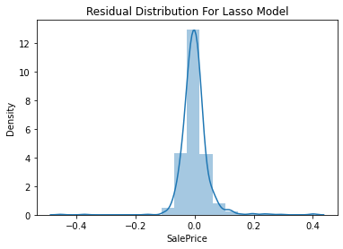

```python
res = y_train - y_train_pred
sns.distplot(res,bins=20)
plt.title('Residual Distribution For Lasso Model')
plt.show()
```

```python
#linear regression assumption hold correct : error is normally distributted
```

# Final Conclusion :

## Ridge Regression : optimal lambda : 10 and Train r2 Score : 87 & Test r2 Score : 85

#### Top 10 Feature of Ridge

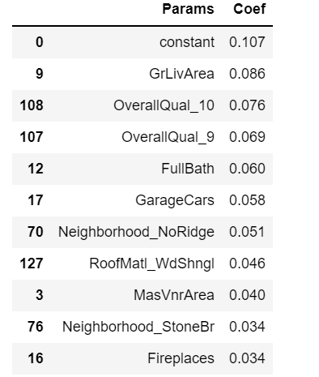

## Lasso Regression : optimal lambda : 0.001 and Train r2 Score : 83 & Test r2 Score : 81

#### Top 10 Feature of Lasso

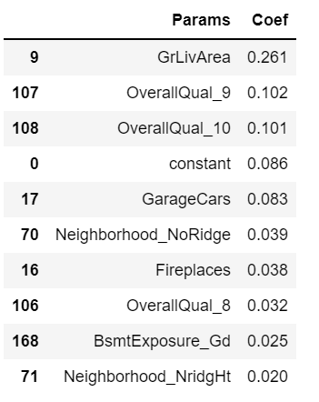